# Homework 2

Author

Jean Jacques Brou

Published

June 1, 2025

## Before your start the assignment

- Update the header - put your name in the `author` argument and put today’s date in the `date` argument.
- Click the “Render” button in RStudio and then open the rendered `2-hw2.html` page.
- Then go back and try changing the `theme` argument in the header to something else - you can see other available themes [here](https://quarto.org/docs/output-formats/html-themes.html). Notice the difference when you render now!

## Overview of HW2

Create a data visualization that helps answer the question:

> **How have the number and cost of billion-dollar disasters in the US changed over time?**

You will use the NOAA Billion-Dollar Disaster dataset to explore how visual encoding choices (e.g., color, position, length) help communicate trends clearly and effectively.

**Skills practiced**:

- Downloading and importing real-world data from a public source (NOAA)
- Wrangle and explore a real-world dataset using tidyverse
- Identify appropriate visual encodings based on variable types and goals
- Create a clear and effective time-series visualization with ggplot2
- Apply design principles (titles, colors, themes, alt text) for accessibility and clarity

### Load Required Packages

```r
library(tidyverse)
library(janitor)
# load other packages as you see fit but remember to add comments to explain what each package does
```

## Q1: Prepare the data

Following these steps to download and read in the dataset:

1. Download the dataset from [NOAA](https://www.ncei.noaa.gov/access/metadata/landing-page/bin/iso?id=gov.noaa.nodc:0209268). Under “Access” tab, choose the HTTPS option to download the data. Scroll to the bottom of the list to download the **most recent published version**. Read more about the dataset [here](https://www.ncei.noaa.gov/access/billions/).
2. Place the downloaded CSV file `events-US-1980-2024-Q4.csv` into your `data/` folder in your HW repository. You will notice there is a graph that comes with the data, we will circle back to it later.
3. Add your data/ folder to .gitignore to avoid pushing data to GitHub.
4. Read in the CSV file using `read_csv()`

```r
# remove the eval=FALSE when you render quarto document
df_disasters <- read_csv("data/events-US-1980-2024-Q4.csv", skip = 2) |>
  janitor::clean_names()
# the skip argument is used to skip the first two rows of the CSV file, which contain metadata about the dataset.
```

5. Skim through the dataset to get familiar with the variable names, especially:
- `disaster`: the type of disaster (e.g., flood, drought, etc.)
- `begin_date`: the date when the disaster began
- `end_date`: the date when the disaster ended
- `cpi_adjusted_cost`: the total damages caused by the disaster (in billions of dollars)
- `deaths`: the number of deaths caused by the disaster
6. Create a new column `year` that extracts the year from the `begin_date` column. You can use the `lubridate` package to do this.

```r
# remove the eval=FALSE when you render quarto document
df_disasters <- df_disasters |>
  mutate(year = lubridate::year(ymd(begin_date)))
```

7. Explore the dataset and answer these questions:
- Are there any missing or zero values in the cost or deaths columns? How might they affect your visualizations?
- What are the top 5 most common disaster types?
- Calculate the total CPI-adjusted cost of disasters per year. Identify the top 3 most expensive years.

```r
#your code here
# counting the number of common types of disaster
top5_disaster <- df_disasters |>
  count(disaster) |> #count the disasters
  arrange(desc(n)) |>  #arrange in descending order to keep most frequent to least frequent disaster
  slice_head(n = 5) #keep the top 5 rows
top5_disaster
```

```
#> # A tibble: 5 × 2
#>   disaster             n
#>   <chr>            <int>
#> 1 Severe Storm       203
#> 2 Tropical Cyclone    67
#> 3 Flooding            45
#> 4 Drought             32
#> 5 Winter Storm        24
```

```r
#your code here
# In the code below I am trying to identify the top 3 expensive years using cpi_adjusted_cost
top3_expensive_years <- df_disasters |>
  group_by(year) |>  # group by year
  summarise(total_CPI_adjusted_cost = sum(cpi_adjusted_cost, na.rm = TRUE)) |>  #summarize cpi_adjusted_cost
  arrange(desc(total_CPI_adjusted_cost)) |> #arrange total summary in descending order to keep most expensive to least expensive
  slice_head( n = 3) #keeping the top 3 rows
top3_expensive_years
```

```
#> # A tibble: 3 × 2
#>    year total_CPI_adjusted_cost
#>   <dbl>                   <dbl>
#> 1  2017                 395936.
#> 2  2005                 268593.
#> 3  2022                 188353.
```

**NoteYour Answer**

- Missing data: There are 101 missing data in the deaths columns only
- 5 most disaster types: Severe Storm (1st), Tropical Cyclone (2nd), Flooding (3rd), Drought(4th), Winter Storm (5th)
- 3 most expensive years by CPI-adjusted cost: 2017, 2005 and 2022 are the 3 most expensive years by CPI-adjusted cost.

## Q2: Build your visualization

Create a data visualization that summarizes trends over time (year or decade) in the frequency and/or cost of disasters.

Your final visualization should:

- Use data from 1980 to 2024 only
- Include a title (short, descriptive), subtitle (main takeaway), caption (e.g., “Data: NOAA Billion-Dollar Disasters (accessed 2025)”)
- Apply strategies for highlighting patterns or trends (e.g., highlighting recent years, distinguishing types of disasters)
- Use custom colors rather than ggplot defaults
- Use a clean, polished theme
- Include at least one theme adjustments (e.g., axis labels, legend position, font size) to improve readability/visual appeal

## comment on my 2 answer:

I did not succeed to create a single visualization with trend and use highlight package to highlight trend. I first visualize disaster observed per year and then created another visualization to display cost per year

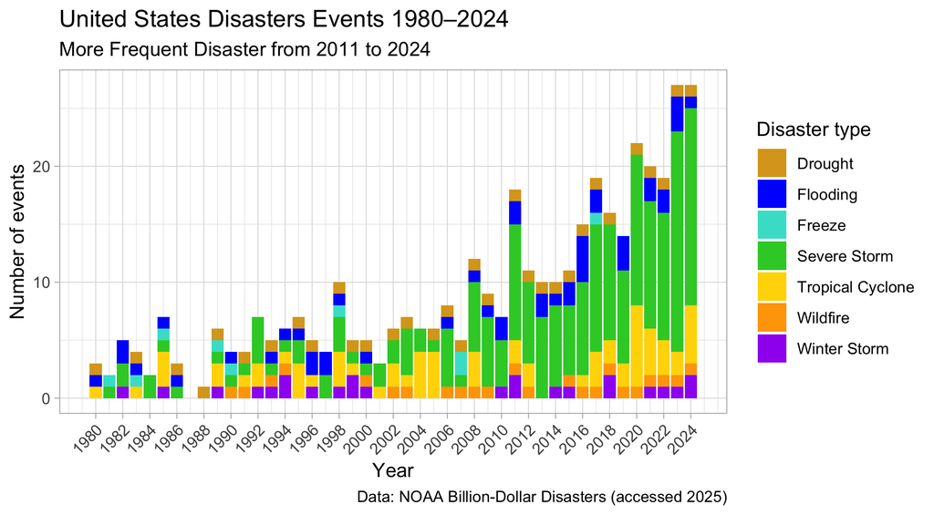

```r
Summary_disaster <- df_disasters |>
  filter(year >= 1980, year <= 2024) |> #filter year 1980-2024
  group_by(year, disaster) |> #group disaster per to display observation per year
  summarise( #summarise number of cpi_adjusted_cost  per year
    count          = n(), #count the number of disaster per year
    total_cpi_cost = sum(cpi_adjusted_cost, na.rm = TRUE), # summarize the total cost per event
    .groups = "drop" #ungroup after summarizing
  )

Prefer_colors <- c( #I had issue with scale_manual, so I am choosing the color this way and then use the object in it
  "Drought"          = "goldenrod",
  "Flooding"         = "blue",
  "Freeze"           = "turquoise",
  "Severe Storm"     = "limegreen",   # bright green
  "Tropical Cyclone" = "gold",
  "Wildfire"         = "orange",
  "Winter Storm"     = "purple"
)

ggplot( #use ggplot to visualize
  Summary_disaster ,
  aes(x = year, y = count, group = disaster, fill = disaster) #representing x and y axis, then fill disaster observed with a color
) +
  geom_col() +
  scale_fill_manual(values = Prefer_colors, name = "Disaster type") + #manually choosing the color, use here the object created obove
  scale_x_continuous(breaks = seq(1980, 2024, by = 2)) + #make all year visible on x axis, year is displayed per 2 year interval
  labs(
    x        = "Year",
    y        = "Number of events",
    title    = "United States Disasters Events 1980–2024",
    subtitle = "More Frequent Disaster from 2011 to 2024",
    caption  = "Data: NOAA Billion-Dollar Disasters (accessed 2025)" #adding a caption
  ) +
  theme_light() +
  theme(
    axis.text.x      = element_text(angle = 45, hjust = 1),
    legend.position  = "right" #adding legend to the right
  )
```

```r
#My code to show annual cost trend
CPI_Year_total <- Summary_disaster |>
  group_by(year) |>
  summarise(
    total_cpi_cost = sum(total_cpi_cost), #summarize cost per year
    .groups = "drop"
  )
CPI_Year_total #to view total cost per year
```

```
#> # A tibble: 44 × 2
#>     year total_cpi_cost
#>    <dbl>          <dbl>
#>  1  1980         45667.
#>  2  1981          3486.
#>  3  1982         15176.
#>  4  1983         26756.
#>  5  1984          3208
#>  6  1985         22515.
#>  7  1986          7870.
#>  8  1988         54610.
#>  9  1989         40331.
#> 10  1990         14589.
#> # ℹ 34 more rows
```

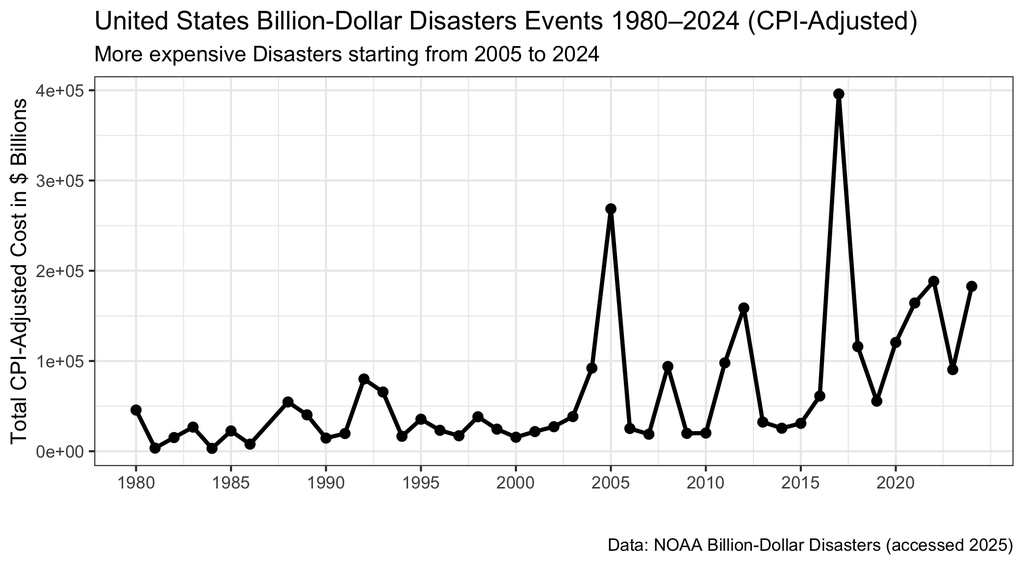

```r
ggplot(CPI_Year_total, aes(x = year, y = total_cpi_cost)) +
  geom_line(linewidth = 1)+ #use geom_line to viualize trend
  geom_point(size =2) + #use geom_point to easily identify costs
    scale_x_continuous(breaks = seq(1980, 2024, by = 5)) + #use this to display year per 5 year interval
   labs(
    title = "United States Billion-Dollar Disasters Events 1980–2024 (CPI-Adjusted)",
    x = "Year",
    y = "Total CPI-Adjusted Cost in $ Billions",
    subtitle = "More expensive Disasters starting from 2005 to 2024",
     caption  = "Data: NOAA Billion-Dollar Disasters (accessed 2025)", #adding a caption
  ) +
  theme_bw() +
  theme(axis.title.x = element_text(
    angle = 50,
    vjust = -0.5,
    hjust = -0.5,
    size = 7
  ))
```

What do you notice about the trends over time in the frequency and/or cost of disasters? Anything unexpected?

**NoteYour Answer**

-2017 has been the most expensive year

-The observed disaster since 1980 are: Drought, Flooding, Freeze, Severe Storm, Tropical Cyclone, Wildfire, Winter Storm

-drought, severe storm, flooding, tropical cyclone are the most frequent disaster since 2011.

## Q3: Reflection

1. What are your variables of interest and what kinds of data (e.g., numeric, categorical, ordered, etc.) are they?

**NoteYour Answer**

The variable of interest from the df_disaster dataset for the HW are: year, disaster, cpi_adjusted cost. year is a numeric data and ordered from 1980 to 2024; cpi_adjusted is a continuous numeric data and disaster is a nominal categorical.

2. How did you decide which type of graphic form was best suited for answering the question? What alternative graphic forms could you have used instead? Why did you settle on this particular form?

**NoteYour Answer**

- the question is about trend over time and that gave me an idea of graph to use

-I decided to used geom_col (to make stacked bar chart) because I have a summary data and it is also suitable to visualize trend over time (reference to class discussion).

-I used line plot to visualize annual cost over time because line plot is suitable to visualize numeric values over time. line display position which is also more effective to show numeric data. With the line chart, we can easily see the trend of cost over time which might be difficult for other chart to display

-I could have used area charts to show the trend of annual disaster cost.

-I could have also use separate bar chart to display disaster observed per year from 1980 to 2024

3. What modifications did you make to this viz to improve readability and accessibility?

**NoteYour Answer**

- I used legend to name what each bar color represent in the graph.
- I used theme_light to remove the default gray background and make background clean

-I used appropriate color that all people can see; I avoid red-green, red-brown combination

-I displayed year on x axis per 2 year interval so that people can easily see years.

-On my second graph, I used theme_bw to whithe background and have grid lines instead of using the default theme

-I used geom_point to display where cost it observed, for example with that we can easily see the minimum cost and year where maximum cost is observed.

-I added title on x and y axis and title to show what the graph is about and what is being observed and subtitle as takeaway

-To highlight to data source, I added caption to show where the data is from and when it was accessed.

4. Is there anything you wanted to implement but didn’t know how? If so, describe it.

**NoteYour Answer**

-I wanted to do a single graph where we can see the disaster per year and then the annual cost.

-I don’t know how to do the second y and combination of geom_col and geom_line here was challenging.

-I first count the type number of event per year with its cost and then calculate total cost per year.

-I don’t know how to move along with the two dataset with ggplot since the second dataset does not contain disaster column.

-Since I did find a solution, that is why I did 2 graphs. because of that I have not be able to highlight patterns or trend.

## Q4: Critique the original graph from NOAA

1. Describe the graphic
- What type(s) of chart(s) are used?
- What variables are encoded? How are they mapped to visual channels (e.g., position, color, size)?
- What is the intended takeaway?

**NoteYour Answer**

-They used stacked bar chart to represent specific disaster trend per year.

- They multiple line charts to display annual cost over time, black line to show 5 year average cost and a grey line to show costs 95 % CI.

-We have several variables encoded : year from 1980 to 2024, disaster frequency (specify per year), annual frequency CPI_adjusted costs in US billion, 5 years average cost,

- Position: on the x axis, each bar represent well the year and y axis, they used line style to show where each value is (number of events and cost in billions); they filled each bar with different color to show the position of the disaster in the year
- size is appropriate and use of different appropriate color help everyone to read the graph.

-The intended to communicate the frequency of disasters and its economic impact for the country from 1980 to 2024.

2. Assess strengths
- What aspects of the chart help communicate the intended message clearly?
- Is there anything done particularly well in terms of accessibility, color use, or labeling?

**NoteYour Answer**

-Title, legend, label of x and y axis help communicate the main message of the graph

- They used excellent color, font size, and labeling which improve readability and accessibility of the graph.

-They particularly made the graph interactive which is great for accessibility. Anyone who move his/her PC mouse to specific year will have detail about the number of each disaster in that year, its costs, combined cost and 95 % CI.

3. Assess limitations
- What elements of the chart are **confusing, cluttered, or potentially misleading**?
- Are any visual encodings hard to interpret?
- Does the chart overcomplicate the message or try to show too much?

**NoteYour Answer**

-The NOAA logo in the background is not visible, they could have added a source - It is hard to interpret the 95% CI they add on the graph, it may mislead general population reading the graph. - The stacked bar may be hard for the general population to identify number of disaster in year unless they click on it. but, they will not have that chance if the graph is printed.

4. Recommend improvements
- Suggest **2–3 specific changes** that would improve the effectiveness of the chart.
- Would you consider separating out the lines from the stacked bars? Using interactivity? Changing the layout?

**NoteYour Answer**

- I would suggest the removal of 95 % CI
- I would suggest them to add a source
- Yes, I would consider separating out from stacked bars. They could have a separate graph to show annual cost. Since it a web graphic, they could a tab to display that.

## BONUS: Create an alternative data visualization from the dataset

- Use the from Data to Viz tool [here](https://www.data-to-viz.com/) to help determine graph types you can use that are different from what you have implemented above
- Create a new visualization that uses a different type of graph than the one you created in Q2.

```r
#your code here
CPI_Year_total <- Summary_disaster |>
  group_by(year) |>
  summarise(
    total_cpi_cost = sum(total_cpi_cost), #summarize cost per year
    .groups = "drop"
  )
CPI_Year_total #to view total cost per year
```

```
#> # A tibble: 44 × 2
#>     year total_cpi_cost
#>    <dbl>          <dbl>
#>  1  1980         45667.
#>  2  1981          3486.
#>  3  1982         15176.
#>  4  1983         26756.
#>  5  1984          3208
#>  6  1985         22515.
#>  7  1986          7870.
#>  8  1988         54610.
#>  9  1989         40331.
#> 10  1990         14589.
#> # ℹ 34 more rows
```

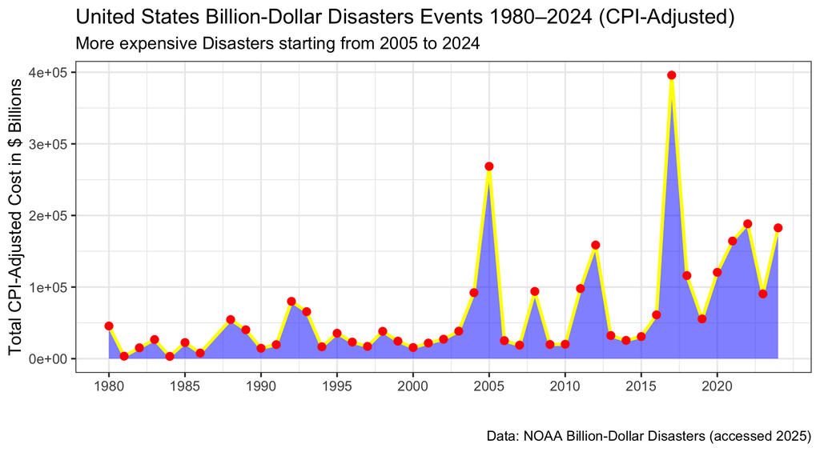

```r
ggplot(CPI_Year_total, aes(x = year, y = total_cpi_cost)) +
  geom_area(fill = "blue", alpha = 0.5)+ #creating area
  geom_line(linewidth = 1, color = "yellow")+ #use geom_line to viualize trend
  geom_point(size =2, color = "red") + #use geom_point to easily identify costs
    scale_x_continuous(breaks = seq(1980, 2024, by = 5)) + #use this to display year per 5 year interval
   labs(
    title = "United States Billion-Dollar Disasters Events 1980–2024 (CPI-Adjusted)",
    x = "Year",
    y = "Total CPI-Adjusted Cost in $ Billions",
    subtitle = "More expensive Disasters starting from 2005 to 2024",
     caption  = "Data: NOAA Billion-Dollar Disasters (accessed 2025)", #adding a caption
  ) +
  theme_bw() +
  theme(axis.title.x = element_text(
    angle = 50,
    vjust = -0.5,
    hjust = -0.5,
    size = 7
  ))
```

**NoteYour Reflection**

I have use area chart to display disaster cost from 1980 to 2024. Overall, I spent a lot of time to do this HW than ususal. The second graph sometime, I don’t why sometime I to zoom out or in before I see it well.

## How I used GenAI?

Describe how GenAI is used in producing this homework, include prompt, date, model version, and link to chat history.

**NoteYour Answer**

I asked Google Gemini pro about the color observed on NOAA website, how to display the cost and disaster on a single graph etc.

AI chart here: https://gemini.google.com/share/d59e770befe6

I also read some example from these book to guide my work: R for Data Science Intro to data analysis with R: https://datawithr.com/

## Save and Push Your Work

Remember to save your `.qmd` and render the HTML output before committing to GitHub.

```bash
git add 2-hw2.qmd 2-hw2.html
git commit -m "Complete Homework 2"
git push
```